# Final Project

Danielle McMillion

2024-12-02

Healthcare Payments Data (HPD) Healthcare Measures is a dataset that contains data in three main categories: Health Conditions, Utilization, and Demographics. It includes the prevalence of long-term illnesses, healthcare usage rates, and demographic information, such as age and health coverage. Furthermore, measures are grouped in various ways, including year, region, and payer type. The objectives for this analysis will to compare payer type, region, year, health coverage, and long-term illnesses to identify possible trends in payer type and health coverage regarding region and long-term illness.

## Table

This table displays the calculated average prevalence of each conditions for Medi-Cal patients across different age bands.

| measure_name | age_band | average_prevalence |
| --- | --- | --- |
| All Combined Cancer Prevalence | 0-17 | 0.0002044 |
| All Combined Cancer Prevalence | 18-34 | 0.0011781 |
| All Combined Cancer Prevalence | 35-49 | 0.0074172 |
| All Combined Cancer Prevalence | 50-64 | 0.0290224 |
| All Combined Cancer Prevalence | 65-74 | 0.0436324 |
| All Combined Cancer Prevalence | 75+ | 0.0553801 |
| Alzheimer’s Disease Prevalence | 50-64 | 0.0007428 |
| Alzheimer’s Disease Prevalence | 65-74 | 0.0058892 |
| Alzheimer’s Disease Prevalence | 75+ | 0.0345969 |
| Anemia Prevalence | 0-17 | 0.0199278 |
| Anemia Prevalence | 18-34 | 0.0269179 |
| Anemia Prevalence | 35-49 | 0.0466792 |
| Anemia Prevalence | 50-64 | 0.0720835 |
| Anemia Prevalence | 65-74 | 0.1070726 |
| Anemia Prevalence | 75+ | 0.1561773 |
| Anxiety Prevalence | 0-17 | 0.0413722 |
| Anxiety Prevalence | 18-34 | 0.0997620 |
| Anxiety Prevalence | 35-49 | 0.1134524 |
| Anxiety Prevalence | 50-64 | 0.1336625 |
| Anxiety Prevalence | 65-74 | 0.0676042 |
| Anxiety Prevalence | 75+ | 0.0555651 |
| Asthma Prevalence | 0-17 | 0.0467478 |
| Asthma Prevalence | 18-34 | 0.0370850 |
| Asthma Prevalence | 35-49 | 0.0410079 |
| Asthma Prevalence | 50-64 | 0.0565211 |
| Asthma Prevalence | 65-74 | 0.0364932 |
| Asthma Prevalence | 75+ | 0.0407963 |
| Atrial Fibrillation (A-Fib) Prevalence | 0-17 | 0.0000654 |
| Atrial Fibrillation (A-Fib) Prevalence | 18-34 | 0.0007813 |
| Atrial Fibrillation (A-Fib) Prevalence | 35-49 | 0.0037557 |

[output cut: 92 more lines]

## Figure

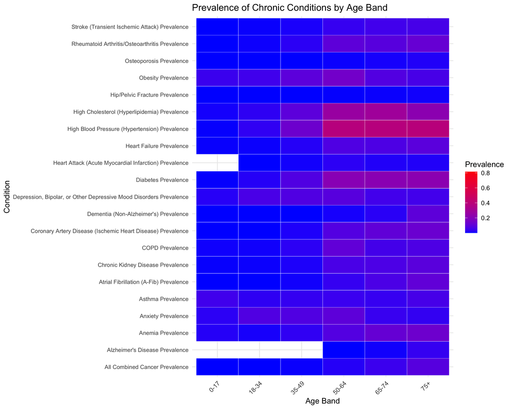